# Biostat 203B Homework 4

Due Mar 24 @ 11:59PM

Author

Shruti Mohanty, 705494615

Load database libraries and the tidyverse frontend:

```r
suppressPackageStartupMessages(library(tidyverse))
suppressPackageStartupMessages(library(tidymodels))
suppressPackageStartupMessages(library(lubridate))
library(dbplyr)
library(DBI)
library(readr)
library(miceRanger)
library(caret)
library(magrittr)
```

## 1 Predicting 30-day mortality

Using the ICU cohort `icu_cohort.rds` you built in Homework 3, develop at least three analytic approaches for predicting the 30-day mortality of patients admitted to ICU using demographic information (gender, age, marital status, ethnicity), first lab measurements during ICU stay, and first vital measurements during ICU stay. For example, you can use (1) logistic regression with elastic net (lasso + ridge) penalty (e.g., glmnet or keras package), (2) random forest, (3) boosting, and (4) support vector machines, or (5) MLP neural network (keras package)

1. Partition data into 50% training set and 50% test set. Stratify partitioning according the 30-day mortality status.

**Solution:**

```r
icu_cohort <- readRDS("icu_cohort.rds")
```

I am performing some pre-processing to remove missing values as my accuracy values were NA if I was using statistical models on the dataset directly. First I have identified variables with more than 5000 NAs. The variables to be discarded are deathtime, edregtime, edouttime, and dod. The outliers are replaced with NAs using the IQR rule.

```r
icu_cohort <- icu_cohort %>%
  select_if(colSums(is.na(icu_cohort)) <= 5000) %>%
  print(width = Inf)
```

```
# A tibble: 53,150 × 37
   subject_id intime               hadm_id  stay_id first_careunit
        <int> <dttm>                 <int>    <int> <chr>
 1   12776735 2200-07-12 00:33:00 20817525 34547665 Neuro Stepdown
 2   16256226 2150-12-20 16:09:08 20013290 39289362 Neuro Stepdown
 3   12974563 2138-11-13 23:30:01 29618057 32563675 Neuro Stepdown
 4   14609218 2174-06-28 21:13:00 20606189 34947848 Neuro Stepdown
 5   12687112 2162-05-31 18:08:45 26132667 37445058 Neuro Stepdown
 6   18190935 2115-11-12 23:23:32 21137829 34338402 Neuro Stepdown
 7   10404210 2161-03-03 18:30:00 22880512 30254828 Neuro Stepdown
 8   12552973 2135-09-21 18:12:03 21320643 30261549 Neuro Stepdown
 9   14303051 2175-11-20 01:02:00 26559537 30401486 Neuro Stepdown
10   12347959 2140-07-11 17:54:14 22779073 30503984 Neuro Stepdown
   last_careunit  outtime               los admittime
   <chr>          <dttm>              <dbl> <dttm>
```

[output cut: 95 more lines]

```r
replace_outliers_with_na <- function(x, factor = 1.5) {
  qnt <- quantile(x, probs=c(0.25, 0.75), na.rm = TRUE)
  h <- factor * IQR(x, na.rm = TRUE)
  x[x < (qnt[1] - h) | x > (qnt[2] + h)] <- NA
  return(x)
}
```

```r
icu_cohort <- icu_cohort %>%
  mutate_if(is.numeric, replace_outliers_with_na)
summary(icu_cohort)
```

```
   subject_id           intime                          hadm_id
 Min.   :10000032   Min.   :2110-01-11 10:16:06.00   Min.   :20000094
 1st Qu.:12483760   1st Qu.:2132-11-03 21:59:53.25   1st Qu.:22478418
 Median :14991992   Median :2152-09-25 12:29:44.00   Median :24948788
 Mean   :14990135   Mean   :2152-10-26 05:18:41.84   Mean   :24976352
 3rd Qu.:17497349   3rd Qu.:2172-10-29 04:56:08.75   3rd Qu.:27477545
 Max.   :19999987   Max.   :2211-05-01 06:59:19.00   Max.   :29999828

    stay_id         first_careunit     last_careunit
 Min.   :30000153   Length:53150       Length:53150
 1st Qu.:32466765   Class :character   Class :character
 Median :34987382   Mode  :character   Mode  :character
 Mean   :34984425
 3rd Qu.:37487830
 Max.   :39999810

    outtime                            los
 Min.   :2110-01-12 17:17:47.00   Min.   :0.001
 1st Qu.:2132-11-06 22:32:25.75   1st Qu.:1.034
 Median :2152-09-28 07:17:57.00   Median :1.695
 Mean   :2152-10-29 13:58:59.61   Mean   :2.139
 3rd Qu.:2172-10-30 21:16:16.50   3rd Qu.:2.866
 Max.   :2211-05-10 22:51:06.00   Max.   :7.216
                                  NA's   :5280
   admittime                        dischtime
 Min.   :2110-01-11 10:14:00.00   Min.   :2110-01-15 17:31:00.00
 1st Qu.:2132-11-01 01:41:45.00   1st Qu.:2132-11-11 14:40:00.00
 Median :2152-09-24 06:45:00.00   Median :2152-10-03 05:40:00.00
 Mean   :2152-10-25 04:22:49.22   Mean   :2152-11-03 14:27:00.51
 3rd Qu.:2172-10-27 23:30:45.00   3rd Qu.:2172-11-07 08:56:15.00
 Max.   :2211-05-01 06:57:00.00   Max.   :2211-05-12 17:54:00.00

 admission_type     admission_location discharge_location  insurance
 Length:53150       Length:53150       Length:53150       Length:53150
 Class :character   Class :character   Class :character   Class :character
 Mode  :character   Mode  :character   Mode  :character   Mode  :character




```

[output cut: 33 more lines]

```
 Min.   : 24.0   Min.   : 96.00   Min.   : 57.0   Min.   : 36.0
 1st Qu.:102.0   1st Qu.: 97.70   1st Qu.:106.0   1st Qu.: 70.0
 Median :121.0   Median : 98.10   Median :122.0   Median : 80.0
 Mean   :127.3   Mean   : 98.15   Mean   :122.9   Mean   : 81.5
 3rd Qu.:147.0   3rd Qu.: 98.60   3rd Qu.:139.0   3rd Qu.: 92.0
 Max.   :235.0   Max.   :100.30   Max.   :188.0   Max.   :127.0
 NA's   :5464    NA's   :4887     NA's   :1262    NA's   :1686
 valuenum220210  valuenum220045  thirty_day_mort
 Min.   : 5.00   Min.   : 37.0   Mode :logical
 1st Qu.:15.00   1st Qu.: 74.0   FALSE:47937
 Median :18.00   Median : 85.0   TRUE :5213
 Mean   :18.23   Mean   : 86.5
 3rd Qu.:21.00   3rd Qu.: 98.0
 Max.   :32.00   Max.   :136.0
 NA's   :1687    NA's   :991
```

Next, I form the table with only the values that are needed for predicting the status of thirty_day_mort.

```r
# Choose the variables needed for prediction of mortality
variables <- c("gender", "anchor_age", "marital_status", "ethnicity", "thirty_day_mort")

lab_item <- c(50912, 50971, 50983, 50902, 50882, 51221, 51301, 50931)
lab_item <- paste("valuenum", lab_item, sep = "")

vital_item <- c(220045, 220181, 220179, 223761, 220210)
vital_item <- paste("valuenum", vital_item, sep = "")

all_vars <- c(variables, lab_item, vital_item)

icu_cohort <- icu_cohort %>%
  select(all_of(all_vars)) %>%
  print(width = Inf)
```

```
# A tibble: 53,150 × 18
   gender anchor_age marital_status ethnicity              thirty_day_mort
   <chr>       <int> <chr>          <chr>                  <lgl>
 1 M              72 MARRIED        OTHER                  FALSE
 2 F              49 SINGLE         OTHER                  FALSE
 3 F              72 WIDOWED        WHITE                  FALSE
 4 F              69 SINGLE         WHITE                  FALSE
 5 M              57 SINGLE         BLACK/AFRICAN AMERICAN FALSE
 6 F              57 DIVORCED       WHITE                  FALSE
 7 F              46 MARRIED        HISPANIC/LATINO        FALSE
 8 F              48 MARRIED        WHITE                  FALSE
 9 F              24 SINGLE         WHITE                  FALSE
10 F              49 MARRIED        WHITE                  FALSE
   valuenum50912 valuenum50971 valuenum50983 valuenum50902 valuenum50882
           <dbl>         <dbl>         <dbl>         <dbl>         <dbl>
```

[output cut: 35 more lines]

Next, I impute the missing values to complete the dataset. This solves the problems of facing NA in accuracy later on.

```r
if (file.exists("icu_cohort_imputed.rds")) {
  icu_cohort_imputed <- read_rds("icu_cohort_imputed.rds")
} else {
  icu_cohort_imputed <- miceRanger(
    icu_cohort,
    m = 1,
    max.depth = 10,
    returnModels = FALSE,
    verbose = TRUE
  )
  icu_cohort_imputed %>% write_rds("icu_cohort_imputed.rds")
}
```

The imputed dataset is chosen using completeData for the rest of the assignment.

```r
icu_cohort <- completeData(icu_cohort_imputed)
icu_cohort <- icu_cohort[[1]]
icu_cohort
```

```
       gender anchor_age marital_status              ethnicity thirty_day_mort
    1:      M         72        MARRIED                  OTHER           FALSE
    2:      F         49         SINGLE                  OTHER           FALSE
    3:      F         72        WIDOWED                  WHITE           FALSE
    4:      F         69         SINGLE                  WHITE           FALSE
    5:      M         57         SINGLE BLACK/AFRICAN AMERICAN           FALSE
   ---
53146:      M         48         SINGLE                  WHITE           FALSE
53147:      F         21         SINGLE                  OTHER           FALSE
53148:      F         55       DIVORCED                  WHITE           FALSE
53149:      F         59         SINGLE                  WHITE            TRUE
53150:      F         77       DIVORCED                  WHITE           FALSE
       valuenum50912 valuenum50971 valuenum50983 valuenum50902 valuenum50882
    1:           1.0           3.3           130            97            22
    2:           0.5           4.0           141           108            21
```

[output cut: 33 more lines]

Data partitioning is done using createDataPartition in a ratio of 0.5 for train and test.

```r
set.seed(10)
icu_cohort$thirty_day_mort= as.factor(icu_cohort$thirty_day_mort)
icu_cohort <- icu_cohort %>%
  mutate_if(is.character, as.factor) %>%
  mutate_if(is.logical, as.factor) %>%
  mutate_if(is.numeric, scale)
index <- createDataPartition(icu_cohort$thirty_day_mort,
                             p = 0.5, list = FALSE)
icu_train <- icu_cohort[index, ]
icu_test <- icu_cohort[-index, ]
```

2. Train and tune the models using the training set.

**Solution:** The first model we use for training is a logistic regression model. The fisher scoring iterations tell us how many iterations are required for the model to converge.

```r
# fit the model
logstc_model <- glm(thirty_day_mort ~ ., icu_train, family = binomial)
summary(logstc_model)
```

```
Call:
glm(formula = thirty_day_mort ~ ., family = binomial, data = icu_train)

Deviance Residuals:
    Min       1Q   Median       3Q      Max
-2.0244  -0.4510  -0.3154  -0.2186   3.1182

Coefficients:
                                  Estimate Std. Error z value Pr(>|z|)
(Intercept)                     -2.7573785  0.4889323  -5.640 1.70e-08 ***
genderM                         -0.1317736  0.0485549  -2.714 0.006649 **
anchor_age                       0.4917519  0.0291284  16.882  < 2e-16 ***
marital_statusMARRIED           -0.0802885  0.0881184  -0.911 0.362220
marital_statusSINGLE            -0.0389483  0.0933796  -0.417 0.676607
marital_statusWIDOWED           -0.0380145  0.0989732  -0.384 0.700913
ethnicityASIAN                   0.2843569  0.4991155   0.570 0.568866
ethnicityBLACK/AFRICAN AMERICAN  0.0211236  0.4895228   0.043 0.965581
ethnicityHISPANIC/LATINO         0.0009836  0.5051553   0.002 0.998446
ethnicityOTHER                   0.2511481  0.4942997   0.508 0.611391
ethnicityUNABLE TO OBTAIN        1.0489375  0.5063479   2.072 0.038305 *
ethnicityUNKNOWN                 1.0603665  0.4857029   2.183 0.029024 *
ethnicityWHITE                   0.1103899  0.4836731   0.228 0.819466
valuenum50912                    0.3501372  0.0219508  15.951  < 2e-16 ***
valuenum50971                   -0.0313252  0.0220802  -1.419 0.155986
valuenum50983                    0.2829317  0.0290508   9.739  < 2e-16 ***
valuenum50902                   -0.4177909  0.0308570 -13.540  < 2e-16 ***
valuenum50882                   -0.4440709  0.0251126 -17.683  < 2e-16 ***
valuenum51221                   -0.0734372  0.0233910  -3.140 0.001692 **
valuenum51301                    0.0822601  0.0217529   3.782 0.000156 ***
valuenum50931                    0.1188377  0.0210616   5.642 1.68e-08 ***
valuenum220045                   0.2096204  0.0234511   8.939  < 2e-16 ***
valuenum220181                   0.0415064  0.0336907   1.232 0.217955
valuenum220179                  -0.2141691  0.0330240  -6.485 8.86e-11 ***
valuenum223761                  -0.1089020  0.0229152  -4.752 2.01e-06 ***
valuenum220210                   0.2403957  0.0230652  10.422  < 2e-16 ***
---
Signif. codes:  0 '***' 0.001 '**' 0.01 '*' 0.05 '.' 0.1 ' ' 1

(Dispersion parameter for binomial family taken to be 1)

    Null deviance: 17055  on 26575  degrees of freedom
Residual deviance: 14420  on 26550  degrees of freedom
AIC: 14472

Number of Fisher Scoring iterations: 6
```

We then predict the probabilities in icu_test with greater than 0.5 being TRUE, and build a confusion matrix.

```r
prob_lg <- predict(logstc_model, icu_test, type = "response")
predict_lg <- ifelse(prob_lg > 0.5, TRUE, FALSE)
table(observed = icu_test$thirty_day_mort, predicted = predict_lg)
```

```
        predicted
observed FALSE  TRUE
   FALSE 23821   147
   TRUE   2408   198
```

```r
cat('Accuracy of test set with logistic regression: ', mean(predict_lg == icu_test$thirty_day_mort))
```

```
Accuracy of test set with logistic regression:  0.9038534
```

The next analytical method I am using is a randomforest. This is a tree based model, and the randomForest package is used.

```r
library(randomForest)
model_rf <- randomForest(icu_train$thirty_day_mort ~ ., data = icu_train, ntree= 100)
```

```r
prob_rf <- predict(model_rf, icu_test, type = "prob")
predict_rf <- predict(model_rf, icu_test)

table(observed = icu_test$thirty_day_mort, predicted = predict_rf)
```

```
        predicted
observed FALSE  TRUE
   FALSE 23871    97
   TRUE   2449   157
```

```r
cat('Accuracy of test set with random forest: ', mean(predict_rf == icu_test$thirty_day_mort))
```

```
Accuracy of test set with random forest:  0.9041921
```

**The Accuracy using a random forest model is 90.41%.** Increasing the number of trees beyond 100 doesn’t change the accuracy a lot.

The third analytical model I used is a gradient boosting model. The gbm package has been used for this.

```r
library(gbm)

icu_train$thirty_day_mort <- as.numeric(icu_train$thirty_day_mort)
icu_test$thirty_day_mort <- as.numeric(icu_test$thirty_day_mort)
# Train the boosting model
boost_model <- gbm(thirty_day_mort ~ ., data = icu_train, n.trees = 100, interaction.depth = 3,
                   distribution = 'gaussian')
```

```r
# Make predictions on the testing data and obtain prediction probabilities
probabilities <- predict(boost_model, icu_test, type = "response")
predict_gbm <- ifelse(probabilities > 0.5, TRUE, FALSE)
cat('Accuracy of test set with boosting: ', mean(predict_gbm == icu_test$thirty_day_mort ))
```

```
Accuracy of test set with boosting:  0.9019342
```

**The Accuracy using a gradient boosting model is 90.19%.** All 3 analytical models gave me comparable performance accuracies on the test set around 90%.

3. Compare model classification performance on the test set. Report both the area under ROC curve and accuracy for each model.

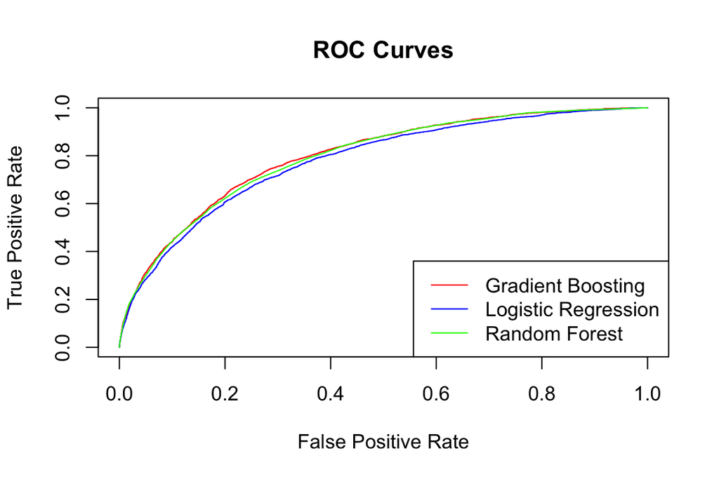

```r
# Create ROC curves
library(ROCR)
glm_pred_roc <- prediction(prob_lg, icu_test$thirty_day_mort)
glm_perf <- performance(glm_pred_roc, "tpr", "fpr")
rf_pred_roc <- prediction(prob_rf[,2], icu_test$thirty_day_mort)
rf_perf <- performance(rf_pred_roc, "tpr", "fpr")
gbm_pred_roc <- prediction(probabilities, icu_test$thirty_day_mort)
gbm_perf <- performance(gbm_pred_roc, "tpr", "fpr")


# Plot ROC curves
plot(gbm_perf, col = "red", main = "ROC Curves", xlab = "False Positive Rate", ylab = "True Positive Rate")
plot(glm_perf, col = "blue", add = TRUE)
plot(rf_perf, col = "green", add = TRUE)
legend("bottomright", c("Gradient Boosting", "Logistic Regression", "Random Forest"), col = c("red", "blue", "green"), lty = 1)
```